# BtrBck - BTRFS Backup Tool

# BtrBck - BTRFS Backup Tool

This backup system is based on the snapshot feature of  
BTRFS. All data of an application is placed in a single BTRFS subvolume. This  
allows instant, atomic snapshots to be taken while the application is running.  
If the application is later restored from the snapshot, it looks to the application  
like an ordinary power loss.

The backup tool operates on so called backup streams. All data in a single stream  
is managed together. Typically, every application is placed in it’s own  
stream. If consistency is required between multiple applications,  
all applications have to be placed in the same stream. However, this means also  
that the applications have to run on the same server.

Backup streams are contained in stream repositories. There are two types of  
repositories: Application stream repositories contain working  
directories upon which applications operate and of which snapshots are  
taken. Backup stream repositories do not contain  
working directories and are only used to replicate streams into.

Streams consist of all working directory snapshots and meta data describing the  
frequency snapshots are taken, the snapshot retention rules,  
the stream version history.

Streams can be replicated between repositories. Replication is only possible  
if a stream is either not contained in the target repository, or if the version  
of the stream of the target repository is a parent version of the to be replicated  
stream. This avoids overwriting new stream versions with old versions and allows  
to detect if multiple application stream repositories are operating on the  
same stream, preventing possible data loss.

Finally, working directories can be restored from a snapshot.

The following diagram shows a class model of the concepts discussed:

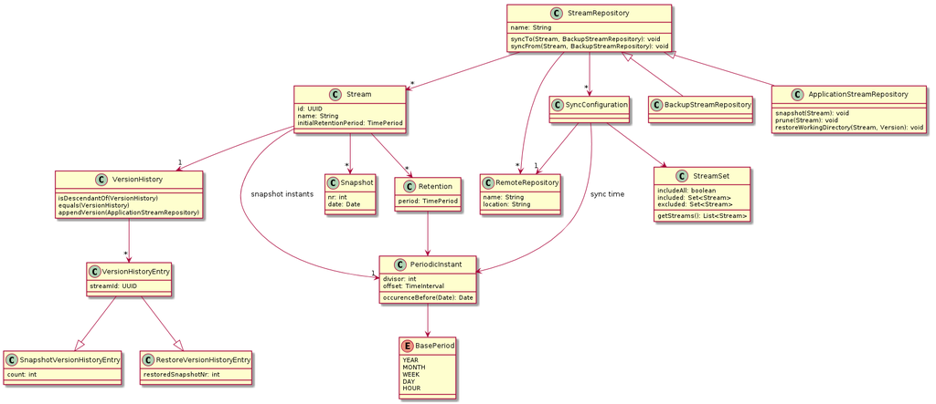

## Versioning

Versioning is used to protect from accidential overwriting of streams. Each stream  
has a version. A derived version of a stream can be created by taking a snapshot.  
The derived from relation is transitive. A version is always considered to derive  
from itself.

Whenever a synchronization between two streams is requested, it is first checked  
if the version of the source stream derives from the version of the target stream.

The **VersionHistory** records on which stream instances snapshots were created.  
This allows for a very compact representation (instance id with count) as long  
as the stream is not transferred frequently between repositories, which is the  
typical use case.

In addition, the history records snapshot restore operations.

## Snapshot Retention and Pruning

Snapshots are protected from pruning by **RetentionRules**. Each rule defines a  
**PeriodicInstant**. The first snapshot after the instant is protected by the rule.  
All snapshots which are not protected are deleted during pruning.

In addition, there is an initial retention period, during which no snapshots are  
pruned.

## Snapshot Clone Sources

Snapshots are transferred as delta to other snapshots. These clone sources are  
the previous and the next snapshots available in the target stream. Since the  
snapshots are numbered, this is trivial as long as no restores come into play.

When looking for the next snapshot, restores are not taken into account. When  
looking for the previous snapshot, the restored snapshot is used as previous  
snapshot instead of the snapshot which was last created before the snapshot  
to be transferred.

## Repository Structure

The base directory of a repository contains the configuration and the snapshots.

Backup stream repositories consist solely of the base directory which is also their  
root directory.

The root directory of an application stream repository contains the working  
directories of the streams in the repository and a “.backup” directory,  
containing the base directory. The working directories are named after the  
respective stream. Each is an individual BTRFS subvolume to allow for atomic  
snapshot.

The location of a repository always points to the root directory.

The base directory contains a “repository.xml” file, defining the repository name,  
the **RemoteRepositories** and the **SyncConfigurations**.

For each stream in the repository there is a sub directory named after the stream. The  
stream directory contains a “stream.xml” file, defining the snapshot frequency, the initial  
retention period and the **Retentions**. The “versionHistory.xml” file contains the version history.  
There is a “snapshots” directory, containing read only  
BTRFS snapshot subvolumes of the working directory.

In application stream repositories, there is an “instanceId.xml” file, containing the id  
of the stream instance. This is required for clean versioning.

## Active Components

All repository modifications are performed by the “btrbck” command line tool.  
Concurrent operations are coordinated by file based locks, either on the  
repository or on the stream level.

Periodic activities are driven by the “btrbckd” daemon. Based on the configuration  
file it triggers snapshots and synchronizations. To avoid inconsistencies, always  
stop the daemon while editing configuration files.

## Concurrency Control

It needs to be possible to perform the following operations in parallel:

- taking snapshots while synchronizing to another repository
- synchronizing multiple streams from other repositories in parallel  
  All other operations can well use a global lock.

BTRBCK uses exclusive and shared file locks for concurrency control. There are the  
following locks:

- Stream enumeration lock: locks the available streams
- Snapshot creation lock (per stream)
- Snapshot removal lock (per stream)

The daemon acquires a shared stream enumeration lock while it is running. Afterwards  
the configuration is parsed and can only be updated by restarting the daemon.

## Operations

### Stream Creation

```
exclusive lock stream enumeration
create base directory
create "stream.xml" with a default configuration
generate stream id
if application stream repository
  create working directory subvolume
unlock stream enumeration
```

### Stream Deletion

```
exclusive lock stream enumeration
delete base directory
if application stream repository
  delete working directory
unlock stream enumeration
```

### Stream Renaming

```
exclusive lock stream enumeration
rename base directory
if application stream repository
  rename working directory
unlock stream enumeration
```

### Taking Snapshots

```
shared lock stream enumeration
exclusive lock snapshot creation
take snapshot
version.append(this)
unlock snapshot creation
unlock stream enumeration
```

### Synchronize to

```
shared lock stream enumeration
call other.synchronizeFrom(this)
unlock stream enumeration
```

### Synchronize from

If a new stream is synchronized to a repository, the daemon of the target repository has to be stopped and  
the new stream has to be created manually.

```
shared lock stream enumeration
exclusive lock snapshot removal
exclusive lock snapshot creation
collect snapshot list
call sendSnapshots
    shared lock stream enumeration
    shared lock snapshot removal
    shared lock snapshot creation
    assert source.versionHistory.isDescendantOf(target.versionHistory)
    determine snapshots to send and clone from
    create pruning list
    unlock snapshot creation
    create/stream send files
    stream pruning list
    unlock snapshot removal
    unlock stream enumeration
receive snapshots
process pruning list
receive versionHistory
receive stream configuration
unlock snapshot creation
unlock snapshot removal
unlock stream enumeration
```

### Pruning Snapshots

```
shared lock stream enumeration
exclusive lock snapshot removal
exclusive lock snapshot creation
perform pruning
unlock snapshot creation
unlock snapshot removal
unlock stream enumeration
```

### Restoring Working Directory

```
shared lock stream enumeration
shared lock snapshot enumeration
restore subvolume
version.appendRestore()
unlock snapshot enumeration
unlock stream enumeration
```